# Part II - (Ford GoBike system Data Exploratory Analysis and Visualization)

## by (Amulya Kandukuri)

## Investigation Overview

> I am investigating the details of Bike trips in Ford GoBike dataset. I am exploring the details about the trips that happen during particular hour, time of day and weekday. I intend to compare trips taken by subscribers and customers in terms of duration in seconds and minutes. I intend to visualize the findings about longest trips, busiest trip taken hours, age of members whether that is customer or subscriber.

## Dataset Overview

> The dataset includes information about bike trips covering San Francisco area. This dataset includes information about various trips like duration_sec, start_time, end_time, start_station_id, start_station_name, start_station_latitude, start_station_longitude, end_station_id, end_station_name, end_station_latitude, end_station_longitude, bike_id, user_type, bike_share_for_all_trip. This dataset mainly focus on rides in February 2019.

## Distribuiton of Bike Trips in day hours

- There is a peak in number of trips taken at 17 th hour and 8th hour of day with more than 20000 times.
- The next most trips are at 9th hour and 18th hour of day with more than 15000 times.
- The least number of trips were taken during 3rd and 4th hours of day with less than 1000 trips

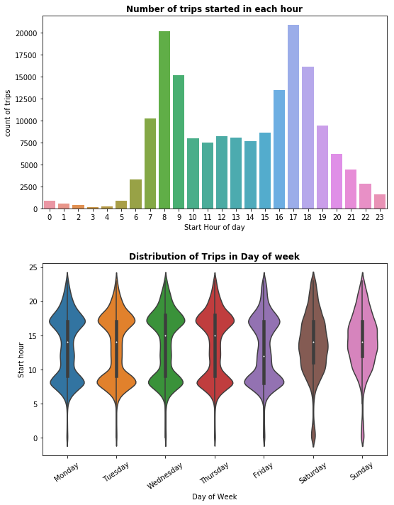

## Weekday Bike Trips

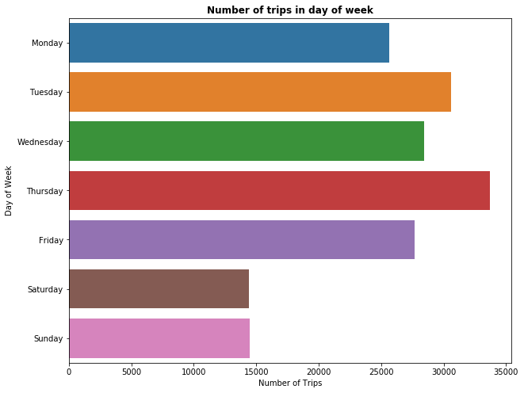

## Distribution of age among members

- The most number of members are in the age 34 years with more than 10000 members.
- The average age of members is 37 years. The minimum age of the members is 21 years.
- The least number of members are in the age above 65 years with less than 1000 members in each year.

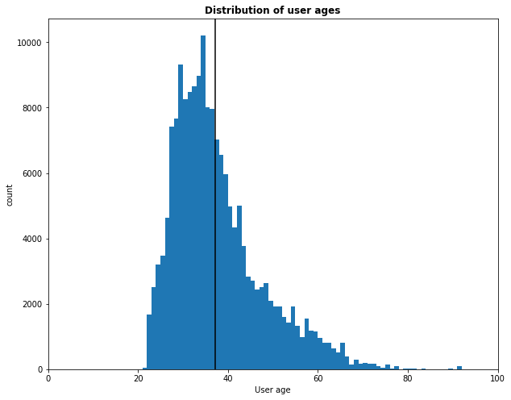

## Distribution of User Types

- There are most number of trips occurred due to subscribers which are approximately 160000.
- The number of customers are below 20000.

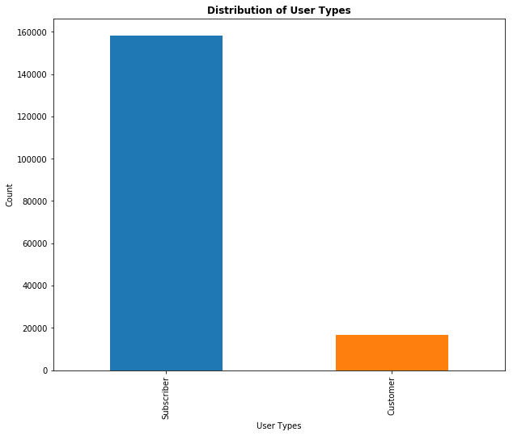

## Average trip duration by day and user type

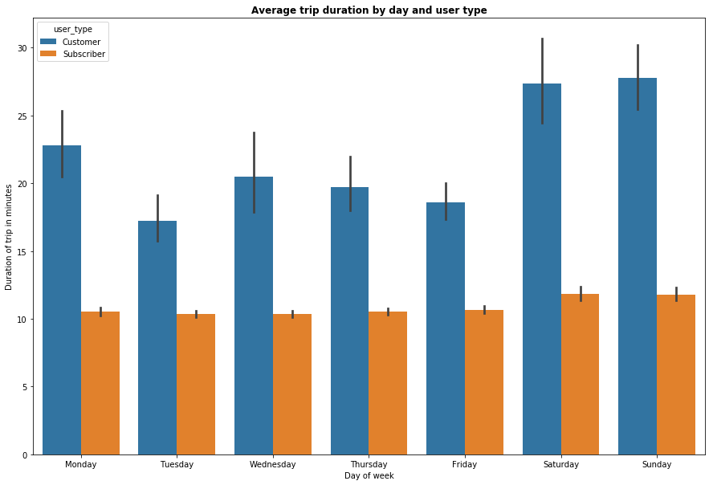